# Does chasing provide an advantage in T20 cricket?

In T20 cricket, teams can either bat first or chase a target. There is a common belief that chasing provides an advantage, as teams know the target they need to reach. This project uses Indian Premier League (IPL) match data to investigate whether chasing teams win more often, and whether this advantage is statistically significant.

The dataset used contains match data from the IPL from 2008-2024, including teams involved, toss decisions and match outcomes.

## Loadng the data

We begin by importing the necessary Python libraries for data analysis and visualisation. The IPL match dataset is then loaded into a dataframe, allowing us to explore its structure and contents.

To analyse whether chasing provides an advantage, we first identify which team batted second in each match. This is determined using the toss decision. We then create a variable called 'chasing_win', which takes the value 1 if the chasing team won the match, and 0 otherwise. This allows us to compare outcomes between teams batting first and second.

## Comparing Win Rates

We calculate the proportion of matches won by teams that were chasing. This provides a simple measure of whether batting second is associated with a higher probability of winning.

```
Chasing win rate: 0.5388127853881278
Batting first win rate: 0.4611872146118722
```

The following chart compares the win rates of teams batting first and those chasing. This provides a clear visual respresenation of any advantage associated with batting second.

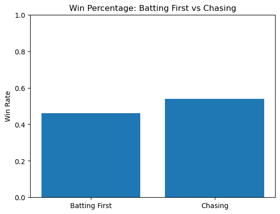

The figure shows that teams batting second (chasing) win approximately 53.8% of matches, compared to 46.2% for teams batting first. This indicates that chasing teams win more frequently, suggesting that batting second is associated with a higher probability of winning in T20 cricket. A reason for this is that majority of IPL games start at 7pm local time, so dew factor comes into play. As the dew settles in the second innings, the ball becomes more slippery and wet, spinners find it harder to grip the ball, yorkers (a ball which aims to be pitched right at the batsman's feet, making it hard to play the ball and score runs) are harder to execute, and fielders struggle in the field due to the wet ball. All of these factors contribute to making chasing easier than batting first. Chasing also allows teams to know what target they need, meaning teams can pace their innings to perfection instead of having to gauge what is a good enough score when batting first.

## Toss Analysis

The toss plays an important role in T20 cricket, as it allows the winning team to choose whether to bat or field. This decision can influence whether a team ends up chasing, and therefore affect match outcomes. We first examine whether winning the toss is associated with a higher probability of winning the match

```
Win rate when winning toss: 0.5059360730593607
Win rate when losing toss: 0.4940639269406393
```

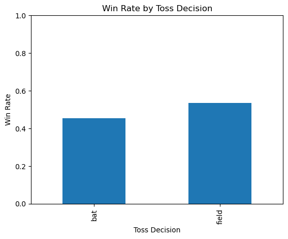

The results show that teams winning the toss have a win rate of approximately 50.6%, which is only slightly above 50%. This suggests that winning the toss does not provide a strong advantage in terms of match outcomes. While the toss allows teams to choose whether to bat or field, its direct impact on winning seems to be limited. This indicates other factors, such as match conditions and team performance, are likely more important in determining the outcome.

## Toss Decisions

We now examine what teams choose to do after winning the toss. In particular, we are interested in whether teams prefer to field, which indicate a preference for chasing.

```
Field first: 0.643
Bat first: 0.357
```

The results show that approximately 64.3% of teams choose to field after winning the toss, compared to 35.7% choosing to bat. This indicates a clear preference for fielding first, suggesting that teams often opt to chase rather than set a target.

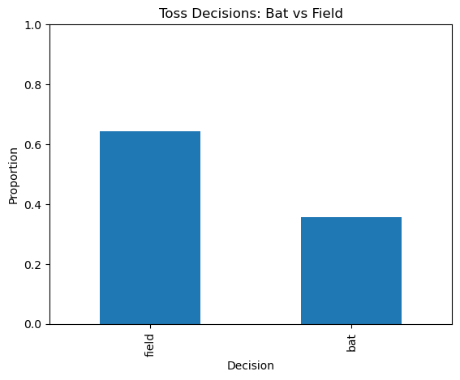

The chart shows how frequently teams choose to bat or field after winning the toss. A higher proportion of teams choosing to field suggests that captains often prefer to chase, which may indicate a perceived advantage in batting second. Again this is because captains understand the value of chasing as chasing on most grounds is easier, and there is less pressure on captains and bowling attacks when it comes to decision making in the second innings. In a format where there are such fine margins, pressure on the bowling attack and fielding side in the second innings can quickly shift the game in the favour of the chasing side. One or two boundaries is enough to change the context of the game, so captains knowing this may prefer to chase.

## Regression Analysis

To further examine the impact of chasing on match outcomes, we use a logistic regression model. The dependent variable is whether team1 won the match, while the independent variable indicates whether team1 was the chasing team. This allows us to test whether being the chasing team is associated with a higher probability of winning.

```
Regression coefficient: 0.462
P-value: 0.001
Pseudo R-squared: 0.008
```

The logistic regression results suggest that being the chasing team is positively associated with winning. The coefficient for team1_chasing is 0.4622, indicating that teams batting second are more likely to win compared to teams batting first. The p-value for this variable is 0.001, which is statistically significant at conventional levels. This suggests that the relationship between chasing and winning is unlikely to be due to random chance. The constant term is not statistically significant (p = 0.167), indicating that the baseline probability of winning when not chasing is not significantly different from zero in this specification. Overall, the results support the earlier descriptive findings, providing evidence that chasing is associated with a higher probability of winning in T20 cricket. However, this should be interpreted as an association rather than a causal relationship, as other factors such as team strength and match conditions may also influence the outcome

## Proportion of Matches Won by Chasing Teams by Season

We examine how the proportion of matches won by chasing teams varies across seasons. This provides further insight into whether the advantage of chasing is consistent over time.

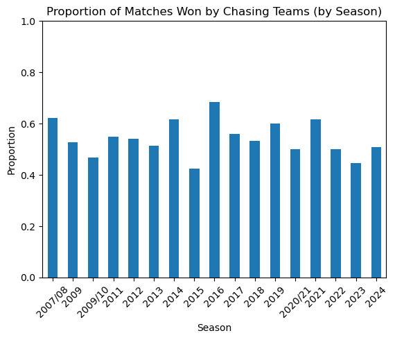

The chart shows the proportion of matches won by chasing teams across seasons. While there are fluctuations, the proportion generally remains around or above 50%, suggesting that the advantage of chasing is relatively stable over time.

## Chasing Advantage by Venue

We examine how the success of chasing varies across different venues. This helps assess whether the advantage of chasing depends on playing conditions such as pitch or location.

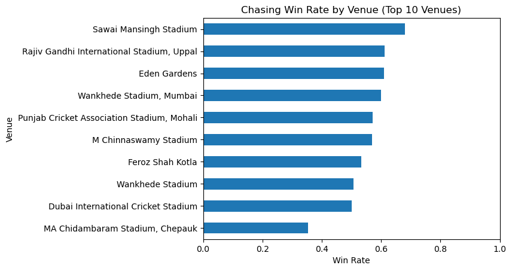

The chart shows that the success of chasing varies across venues. This suggests that local conditions, such as pitch characteristics and ground size, may influence match outcomes. While chasing appears to provide an advantage overall, its effectiveness is not consistent across all venues, indicating that context plays an important role. At venues such as the Chepauk, where spin is more condusive and temperatures are higher, the dew factor comes less into play, meaning setting a score may actually be easier, whereas grounds like Eden Gardens of Kolkata are more condusive to chasing.

## Conclusion

This project investigated whether chasing provides an advantage in T20 cricket using IPL match data. The analysis shows that teams batting second win a higher proportion of matches (approximately 53.8%) compared to teams batting first (46.2%), suggesting that chasing is associated with a higher likelihood of winning. The toss analysis revealed that winning the toss does not significantly increase the probability of winning, but teams overwhelmingly choose to field after winning the toss. This indicates a strong preference for chasing, suggesting that teams believe it provides a strategic advantage. The regression analysis further supports this finding, showing that being the chasing team is positively and significantly associated with winning. However, the venue analysis demonstrates that this advantage is not consistent across all conditions, indicating that factors such as pitch characteristics and playing environment also influence outcomes. A limitation of this analysis is that it does not control for factors such as team strength, player performance, or match conditions, which may also influence match outcomes. Overall, the results suggest that chasing appears to provide a small advantage in T20 cricket, although it is not the only factor determining match results.